# Altermap 2026 : perception des maillages territoriaux au Sénégal

Auteur·rice

Cheikh BA

Date de publication

2026-05-14

## Introduction

Nous proposons ici un premier dépouillement des réponses au questionnaire-test administré à 27 étudiants de licence 2 à l’IGTDL de Dakar le 12 mai 2026. Les calculs ont été effectués par C. Grasland à l’aide d’un programme R de statistiques et cartographie qui pourra être relancé au fur et à mesure que l’échantillon sera plus étoffé ou sur d’autres échantillons.

# A. QUELQUES QUESTIONS SUR VOUS

La première partie du questionnaire apportait des données de cadrage sur les individus (âge, sexe) et sur l’origine géographiuque et les trajectoires de mobilité des étudiants.

**Télécharger le jeu de données issues de Kobo Toolbox**

- [Données d’enquête issus de kobo au format label .xlsx](https://github.com/worldregio/altermap/raw/refs/heads/main/data/axe4/ALTERMAP_2026_Gouvernance_Sénégal_V1.xlsx)

On commence par charger les questionnaires issus de Kobo Toolbox en format “label” (texte complet)

## A.1 Sexe

```
           n   %
Un homme  10  37
Une femme 17  63
Total     27 100
```

- **Commentaire** :

## A.2 Âge

On doit corriger une valeur aberrante …

```
       n     %
20     7  26.9
21     7  26.9
22     7  26.9
23     2   7.7
24     3  11.5
Total 26 100.0
```

- **Commentaire** :

## Nationalité

Dans 8 questionnaires on ne trouve aucune réponse sur les pays de naissance de l’individu, son père et sa mère.

### A.3.1 Pays de naissance de l’individu

```
         n     %
Sénégal 18  66.7
NA       9  33.3
Total   27 100.0
```

### A.3.2 Pays de naissance de son père

```
         n     %
Guinée   2   7.4
Sénégal 17  63.0
NA       8  29.6
Total   27 100.0
```

### A.3.3 Pays de naissance de sa mère

```
               n     %
Côte d'Ivoire  1   3.7
Sénégal       18  66.7
NA             8  29.6
Total         27 100.0
```

- **Commentaire** :

## A.4 Département de naissance de l’individu

N.B. Un étudiant n’a pas répondu

```
             n     %
Dakar        4  14.8
Diourbel     1   3.7
Fatick       1   3.7
Gossas       1   3.7
Guédiawaye   1   3.7
Kaolack      2   7.4
Matam        1   3.7
Mbacké       1   3.7
Mbour        1   3.7
Oussouye     1   3.7
Pikine       3  11.1
Rufisque     2   7.4
Saint-Louis  1   3.7
Tambacounda  1   3.7
Thiès        1   3.7
Tivaouane    3  11.1
Ziguinchor   1   3.7
NA           1   3.7
Total       27 100.0
```

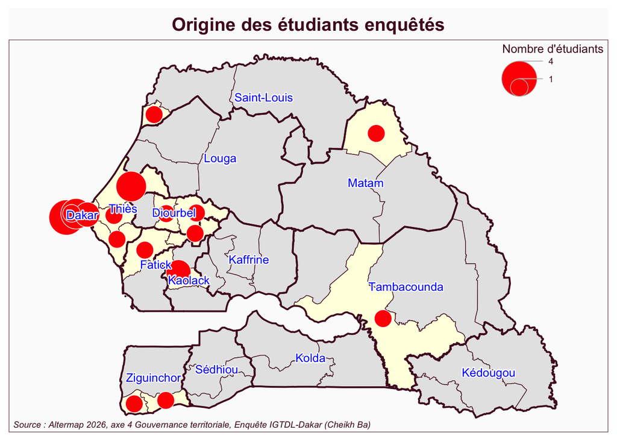

- **Commentaire** :

## A.5 Mobilité interne et trajectoires

### Changement de communes

Réponses à la question des mobilités internes au pays.

```
       n     %
Oui   12  44.4
Non   15  55.6
Total 27 100.0
```

### Trajectoires

On ne traitera pas ici les parcours qui nécessitent un recodage long des réponses. On affiche juste le tableau des trajectoires des étudiants déclarant avoir changé de commune.

Trajectoire des étudiants ayant changé de commune

| id | sex | dep_nais | traj |
| --- | --- | --- | --- |
| L2-001 | Un homme | Ziguinchor | Commune de Mlomp, Commune de Kafontine, Commune de Thiés, Commune de Kayar, Commune de Ouakam, Commune de Ziguinchor |
| L2-002 | Une femme | Gossas | Thiaré Ndialgui |
| L2-003 | Une femme | Mbacké | Touba , parcelles assainies , Foire |
| L2-004 | Une femme | Dakar | Keur Massar Nord |
| L2-006 | Un homme | Oussouye | Marsassoum |
| L2-007 | Une femme | Guédiawaye | Thiaroye; Rufisque |
| L2-008 | Une femme | Pikine | Thiaroye , Rufisque |
| L2-012 | Une femme | Dakar | Dakar,Thies,Fatick |
| L2-015 | Une femme | Diourbel | Mbour |
| L2-019 | Une femme | Dakar | Parcelles Assainies, Thiaroye, et Mbour |
| L2-022 | Un homme | Dakar | Thiès, fatick, kolda, zinguinchor |
| L2-027 | Une femme | NA | La commune de Ouakam |

- **Commentaire** :

# B. SENTIMENT D’APPARTENANCE TERRITORIALE

## B.1 Echelle d’appartenance

### Echelles citées

On peut tout d’abord examiner quelles échelles ont été les plus mobilisées par les étudiants sans distinguer l’ordre

```
[1] "1. Quartier/Village/Commune"
[2] "2. Département-Arrondissement"
[3] "3. Région administrative"
[4] "4. Pays (Sénégal)"
[5] "5. sous-continent (Afrique de l'Ouest"
[6] "6. Continent (Afrique)"
```

```
              n     %
1. Local     36  44.4
2. Dept-Ardt  3   3.7
3. Region    15  18.5
4. Pays      15  18.5
5.Sous-cont.  6   7.4
6. Continent  6   7.4
Total        81 100.0
```

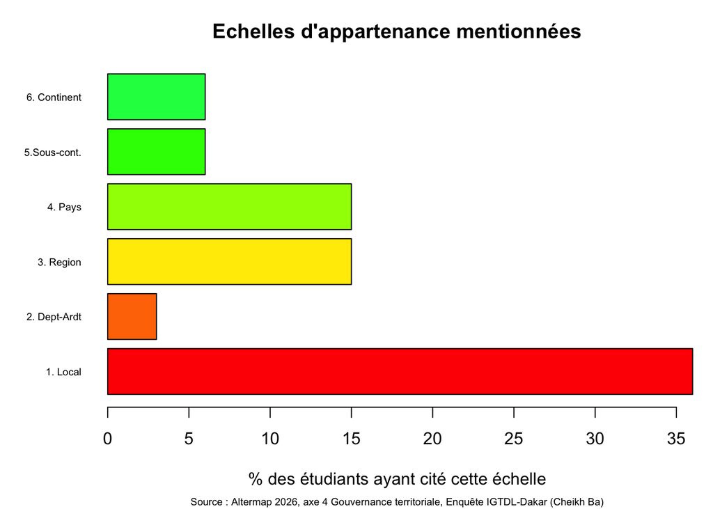

### Echelle citée en premier

On peut ensuite se focaliser sur le premier choix

```
              n     %
1. Local     12  44.4
2. Dept-Ardt  1   3.7
3. Region     5  18.5
4. Pays       5  18.5
5.Sous-cont.  2   7.4
6. Continent  2   7.4
Total        27 100.0
```

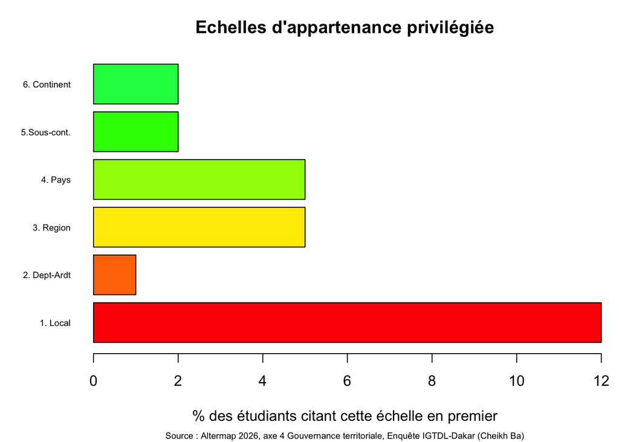

- **Commentaire** :

## B.2 Sentiment d’appartenance à des régions non officielles

Cette question interrogeait les étudiants sur leur sentiment d’apprtenance à des espaces non officiels.

### Nombre de réponses

Certains ont déclaré des appartenances à plusieurs régions.

```
       n     %
1     20  76.9
2      5  19.2
3      1   3.8
Total 26 100.0
```

### Réponses les plus fréquentes

On évalue les régions les plus fréquemment citées.

| region | n | pct |
| --- | --- | --- |
| Sine Saloum | 11 | 33.3 |
| Autre | 7 | 21.2 |
| Casamance | 6 | 18.2 |
| Cayor | 5 | 15.2 |
| Baol | 4 | 12.1 |
| Gabu | 0 | 0.0 |
| Boundou | 0 | 0.0 |

### Autres réponses

On détaille les réponses “*Autre*” qui ont été proposées par certains étudiants :

```
       Fouta toro       Tambacounda          Tengueth              Walo
                3                 1                 1                 1
Walo, Saint Louis
                1
```

- **Commentaire** :

## B.3 Régions attractives et répulsives

Une manière simple mais efficace de mettre à jour les représentations du Sénégal des étudiants a consisté à leur demander de citer trois régions pays où ils souhaiteraient vivre ou ne pas vivre dans un futur proche. Cela suppose une petite transformation des données pour créer un tableau ou chaque ligne correspond à une réponse sur les pays attractifs ou répulsifs. En d’autres termes les réponses de chaque étudiant correspondront à 6 lignes, 3 pour les régions cités positivement et 3 pour les régions cités négativement.On accompagnera ces réponses des informations que l’on juge utile sur les étudiants afin de pouvoir ensuite faire des regroupements.

A titre d’exemple, voici la forme que prennent les réponses d’un étudiant :

| id | sex | age | dep_nais | traj | Autre_rep | opi | rnk | NAME_1 |
| --- | --- | --- | --- | --- | --- | --- | --- | --- |
| L2-022 | Un homme | 21 | Dakar | Thiès, fatick, kolda, zinguinchor | Fouta toro | neg | 1 | Tambacounda |
| L2-022 | Un homme | 21 | Dakar | Thiès, fatick, kolda, zinguinchor | Fouta toro | neg | 2 | Kolda |
| L2-022 | Un homme | 21 | Dakar | Thiès, fatick, kolda, zinguinchor | Fouta toro | neg | 3 | Fatick |
| L2-022 | Un homme | 21 | Dakar | Thiès, fatick, kolda, zinguinchor | Fouta toro | pos | 1 | Ziguinchor |
| L2-022 | Un homme | 21 | Dakar | Thiès, fatick, kolda, zinguinchor | Fouta toro | pos | 2 | Sédhiou |
| L2-022 | Un homme | 21 | Dakar | Thiès, fatick, kolda, zinguinchor | Fouta toro | pos | 3 | Thiès |

-**Commentaire :** L’étudiant L2-022 est un homme de 21 ans, né à Dakar, qui a le sentiment d’appartenir à la région de Fouto Toro et a vécu dans de nombreuses communes du pays. Il déclar qu’il ne souhaiterait pas vivre dans les régions de Tambacoubda, Kolda et Falick. Mais il aimerai bien vivre dans les régions de Zinguichor, Sédhiou ou Thiès. On peut remarquer qu’il cite les quatre régions ou il a véu, soit positivement (Zinguichor, Thiès), soit négativement (Fatick, Kolda) mais pas Dakar où il est né.

### Régions attractives

Si on ne tient pas compte du rang des réguons cités positivement, on peut établir un tableau de fréquence indiquant le nombre de fois ou une région a été cité positivement par l’un des étudiants de notre échantillon.

Régions les plus attractives pour les étudiants

| Rang | Nom | Nb. réponses | % étudiants |
| --- | --- | --- | --- |
| 1 | Saint-Louis | 23 | 85.2 |
| 2 | Dakar | 17 | 63.0 |
| 3 | Thiès | 15 | 55.6 |
| 4 | Ziguinchor | 9 | 33.3 |
| 5 | Kaolack | 5 | 18.5 |
| 6 | Fatick | 3 | 11.1 |
| 7 | Diourbel | 2 | 7.4 |
| 11 | Kaffrine | 1 | 3.7 |
| 11 | Kolda | 1 | 3.7 |
| 11 | Kédougou | 1 | 3.7 |
| 11 | Louga | 1 | 3.7 |
| 11 | Matam | 1 | 3.7 |
| 11 | Sédhiou | 1 | 3.7 |
| 11 | Tambacounda | 1 | 3.7 |

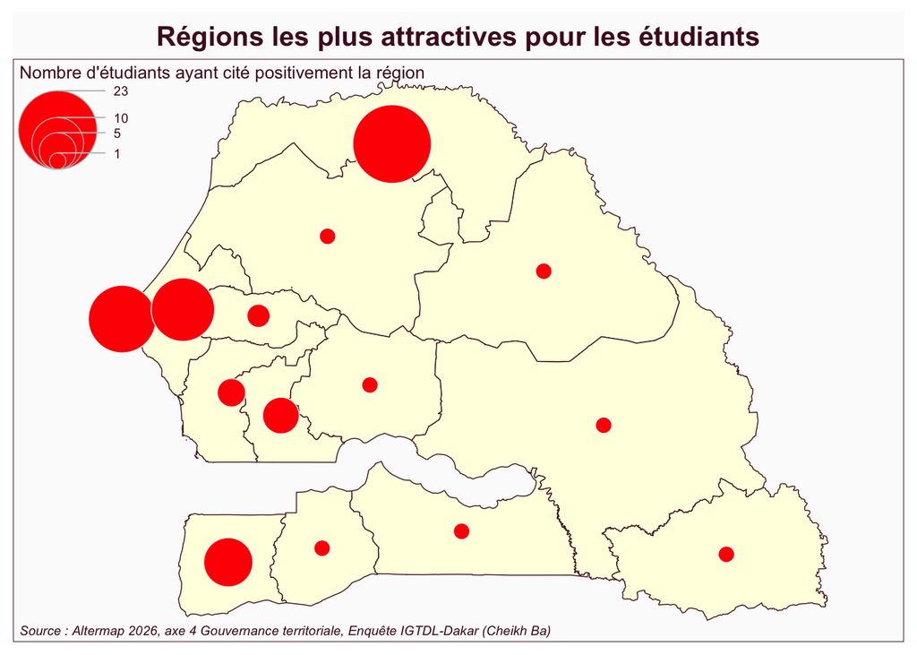

- **Commentaire** :

### Régions répulsives

Régions les plus répulsives pour les étudiants

| Rang | Nom | Nb. réponses | % étudiants |
| --- | --- | --- | --- |
| 1 | Tambacounda | 19 | 70.4 |
| 2 | Matam | 12 | 44.4 |
| 3 | Kolda | 11 | 40.7 |
| 4 | Kaolack | 7 | 25.9 |
| 4 | Kédougou | 7 | 25.9 |
| 6 | Kaffrine | 5 | 18.5 |
| 6 | Louga | 5 | 18.5 |
| 8 | Fatick | 4 | 14.8 |
| 8 | Sédhiou | 4 | 14.8 |
| 10 | Diourbel | 3 | 11.1 |
| 10 | Ziguinchor | 3 | 11.1 |
| 12 | Dakar | 1 | 3.7 |

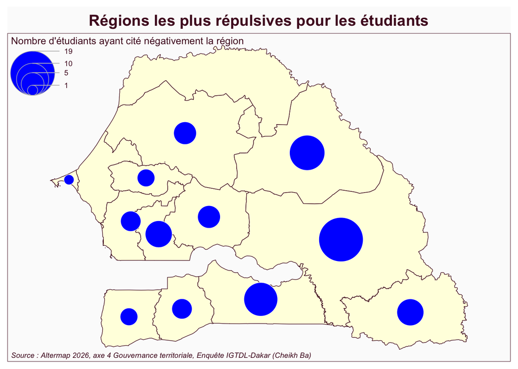

- **Commentaire** :

### Synthèse

L’appréciation que les étudiants donnent d’une région doit être envisagé selon deux dimensions complémentaires, la saillance et l’opinion

- **la saillance** (en anglais *salience*) est le fait qu’une régionse présente à l’esprit dun étudiant lorsqu’on lui demande de porter un jugement. Peu importe que le jugement soit positif ou négatif, si une région est citée par l’étudiant c’est qu’il possède des informations sur elle, qu’il en a reçu et à choisi de les retenir. Bref, la saillance manifeste une reconnaissance de l’existence d’une région et signale sa présence dans la carte mentale de la personne. On la définira donc comme le % des étudiants qui ont cité une région, positivement ou négativement, peu importe, et on la mesurera sur une échelle de 0 (jamais citée) à 100 (toujours citée) :

$Saillance_i = 100\times \frac{Pos_i + Neg_i}{n}$

$Polarisation_i = \frac{Pos_i-Neg_i}{Pos_i+Neg_i}$

### Tableau de synthèse

Saillance et attractivité des régions du Sénégal

| Nom | Négatif | Positif | Total | Saillance (%) | Polarisation |
| --- | --- | --- | --- | --- | --- |
| Saint-Louis | 0 | 23 | 23 | 85.2 | 1.00 |
| Tambacounda | 19 | 1 | 20 | 74.1 | -0.90 |
| Dakar | 1 | 17 | 18 | 66.7 | 0.89 |
| Thiès | 0 | 15 | 15 | 55.6 | 1.00 |
| Matam | 12 | 1 | 13 | 48.1 | -0.85 |
| Kaolack | 7 | 5 | 12 | 44.4 | -0.17 |
| Kolda | 11 | 1 | 12 | 44.4 | -0.83 |
| Ziguinchor | 3 | 9 | 12 | 44.4 | 0.50 |
| Kédougou | 7 | 1 | 8 | 29.6 | -0.75 |
| Fatick | 4 | 3 | 7 | 25.9 | -0.14 |
| Kaffrine | 5 | 1 | 6 | 22.2 | -0.67 |
| Louga | 5 | 1 | 6 | 22.2 | -0.67 |
| Diourbel | 3 | 2 | 5 | 18.5 | -0.20 |
| Sédhiou | 4 | 1 | 5 | 18.5 | -0.60 |

### Graphique de synthèse

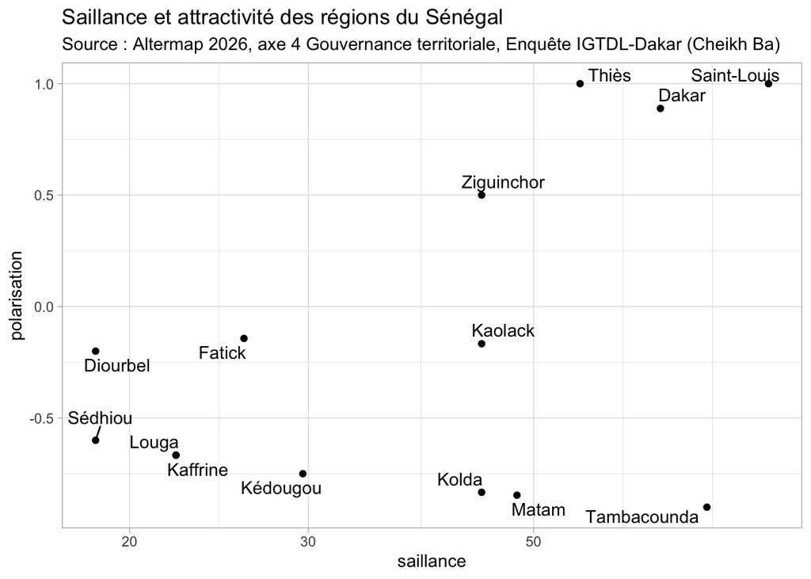

### Cartogramme

On déforme la surface des régions pour leur donner une superficie prportionnelle à leur saillance, c’est-à-dire au nombre de fois où ils ont été cités. Puis on les colorie en fonction de la valeur de l’indice de polarisation , de rouge foncé pour les régions les plus répulsives à bleu foncé pour les plus attractives, en passant par jaune clair pour les régions neutres qui ont autant d’avis positis que négatifs.

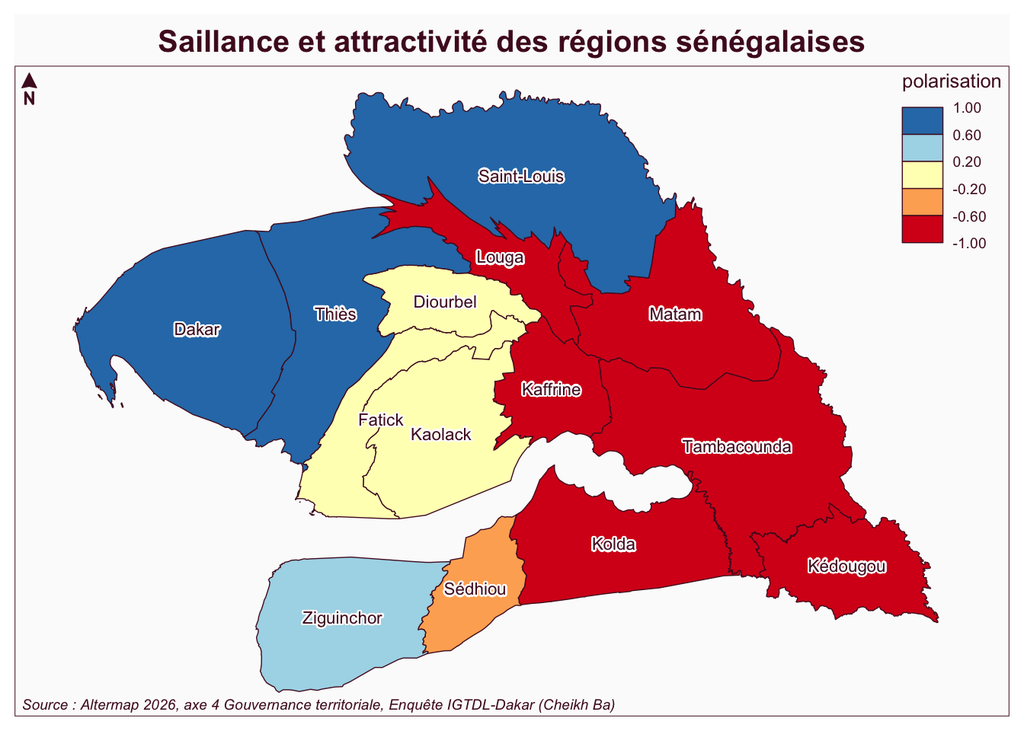

- **Commentaire** :

## B.4 Royaume et entités historiques précoloniales

### Connaissance

```
       n   %
Non   17  63
Oui   10  37
Total 27 100
```

### Nom

```
                  n   %
Cabrousse         1  10
Cayor             4  40
Fouladou          1  10
Fouta Toro        1  10
Le sine saloum    1  10
Royaume du cayor  1  10
Saloum            1  10
Total            10 100
```

- **Commentaire** :

## B.5 Mots associés aux royaumes

On ne retient que les 10 mots les plus fréquents pour construire les nuages de mots ci-dessous

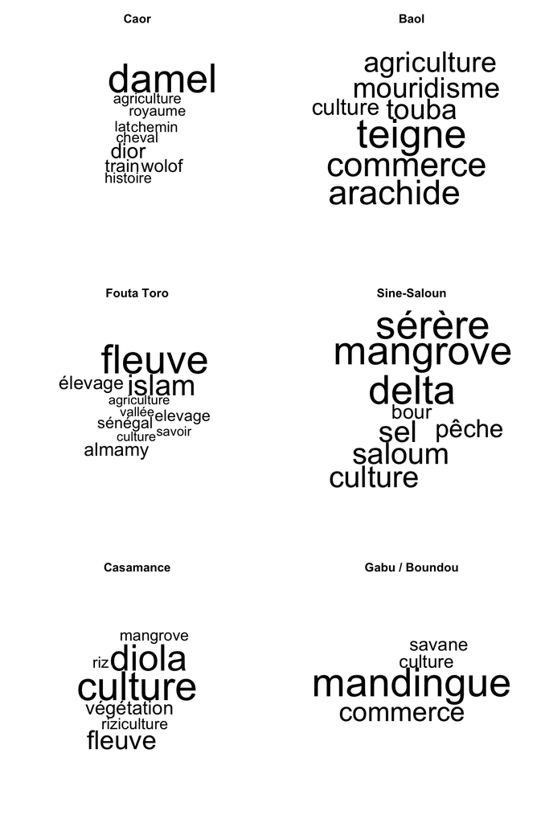

- **Commentaire** :